# Stat 380: MiniProject 1

Sammit Bal, Thaddeus Poff, Jason Zhang

## Front Matter

```r
library(tidyverse)
library(lubridate)
library(readxl)
library(knitr)
```

## Read the dataset into R

```r
COD_dataset <- read_excel("./CODGames2_mp.xlsx")
```

## Introduction to the Dataset

The dataset “COD Games” refers to the video game Call of Duty. The dataset contains 27 variables, including “Map 1”, “Map 2”, “Choice”, “Map Vote”, “Date”, and “Full Partial”.

```r
head(COD_dataset)
```

```
## # A tibble: 6 × 27
##   Map1  Map2  Choice MapVote Date                FullPartial Result Eliminations
##   <chr> <chr> <chr>  <chr>   <dttm>              <chr>       <chr>         <dbl>
## 1 Mosc… Miam… Miami… 5 to 0  2022-06-06 00:00:00 Full        100-97           22
## 2 Mosc… WMD   Moscow 2 to 0  2022-06-06 00:00:00 Full        76-89            20
## 3 <NA>  <NA>  Yaman… <NA>    2022-06-06 00:00:00 Full        100-92           18
## 4 Driv… Jung… Drive… 2 to 0  2022-06-06 00:00:00 Full        80-100           10
## 5 Coll… Hija… Colla… 3 to 3  2022-06-06 00:00:00 Full        71-100           11
## 6 Cros… Raid  Raid   4 to 3  2022-06-06 00:00:00 Full        85-100            7
## # ℹ 19 more variables: Deaths <dbl>, Score <dbl>, Damage <dbl>, TotalXP <dbl>,
## #   PrimaryWeapon <chr>, XPType <chr>, DidPlayerVote <chr>, GameType <chr>,
## #   Confirms <dbl>, Denies <dbl>, Objectives <dbl>, ObjectiveKills <dbl>,
## #   Captures <dbl>, Diffuses <lgl>, Plants <lgl>, Detonates <lgl>,
## #   Deposits <lgl>, Time_Sec <dbl>, Time_Min <dbl>
```

Each row represents one game of COD, though what a “game” entails— be it the Result or statistics— seems to vary case by case. In total, there are 211 games:

```r
nrow(COD_dataset)
```

```
## [1] 211
```

Overall, there are several times that “Map1”, “Map2”, and “MapVote” are not recorded— instead left as NA— but, for the most part, the NAs are prevalent in the variables “Confirms”, “Denies”, “Objectives”, and the rest of the variables to the right.

**Notes for Our Group:**

1. Each row represents a game
2. We’re interested in the variables “PrimaryWeapon”, “Score”, “Choice”, “Eliminations”, “TotalXP”

## Variable 1 (PrimaryWeapon)

We were curious about the variable “PrimaryWeapon”, which seems to refer to the most common weapon selected for a round. Based on the dataset, there are 9 different types of weapons:

```r
# Table of types of PrimaryWeapon
COD_dataset %>%
  dplyr::select(PrimaryWeapon) %>%
  distinct()
```

```
## # A tibble: 9 × 1
##   PrimaryWeapon
##   <chr>
## 1 M16
## 2 MP5
## 3 AK-47
## 4 Krig 6
## 5 QBZ-83
## 6 Pelington 703
## 7 FFAR 1
## 8 Type 63
## 9 MG 82
```

The statistics collected from the rounds recorded contained no NA values for PrimaryWeapon:

```r
# Filter: Find the number of NA values in PrimaryWeapon
COD_dataset %>%
  filter(is.na(PrimaryWeapon)) %>%
  summarize(Number_of_NA = n())
```

```
## # A tibble: 1 × 1
##   Number_of_NA
##          <int>
## 1            0
```

**Visualization:**

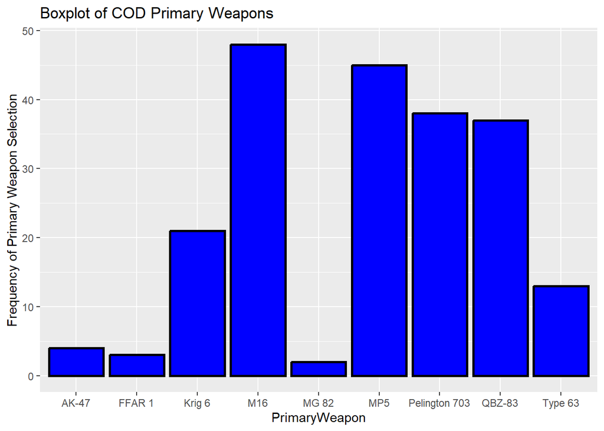

```r
# Aggregate of Primary Weapon counts per unique Primary Weapon
COD_PW_df <- COD_dataset %>%
  select(PrimaryWeapon) %>%
  group_by(PrimaryWeapon) %>%
  summarize(N = n())

# Boxplot visualization of Primary Weapon counts
ggplot(data = COD_PW_df,
       mapping = aes(x = PrimaryWeapon, y = N)) +
  geom_bar(stat = "identity", fill = "blue",
           linewidth = 1, colour = "black") +
  labs(y = "Frequency of Primary Weapon Selection",
       title = "Boxplot of COD Primary Weapons")
```

**Analysis:**

Based on this analysis, the frequency of weapon selections ranges from the MG 82 which is selected only twice, to the M16 which is selected 48 times, for a total of 211 games’ worth of Primary Weapons data.

- Most weapons— 5 out of 9, to be exact— are selected more than twenty times: the Kric 6 21 times, the QBZ-83 37 times, the Pelington 703 38 times, the MP5 45 times, and the M16 48 times.
- There are four weapons selected less than twenty times: the Type 63 only 13 times, the AK-47 4 times, the FFAR 1 3 times, and the MG 82 2 times.

Between the categories, there is a wide gulf between the frequently-used weapons and infrequently-used ones. Almost all of the frequently-used weapons are used above 35 times, and almost all of the less-frequently-used weapons are used below 5 times.

This suggests the existance of a “META” (Most Effective Tactic Available) between COD weapons, where some weapons which are (most likely due to their being statistically less effective) broadly ignored by a player base, while other weapons are commonly selected.

## Variable 2 (Score)

For the second variable, we selected Score a quantitative variable. This variable contains numeric data, which ranges in values from 100 to 7315.

There are no missing observations for the Score variable.

```r
# Filter: Find the number of NA values in Score
COD_dataset %>%
  filter(is.na(Score)) %>%
  summarize(Number_of_NA = n())
```

```
## # A tibble: 1 × 1
##   Number_of_NA
##          <int>
## 1            0
```

```r
# Summary statistics for Score variable
COD_dataset %>%
  select(Score) %>%
  summarize(min = min(Score),
    max = max(Score),
    mean = mean(Score),
    median = median(Score),
    sd = sd(Score))
```

```
## # A tibble: 1 × 5
##     min   max  mean median    sd
##   <dbl> <dbl> <dbl>  <dbl> <dbl>
## 1   100  7315 2945.   2770 1465.
```

**Visualization:**

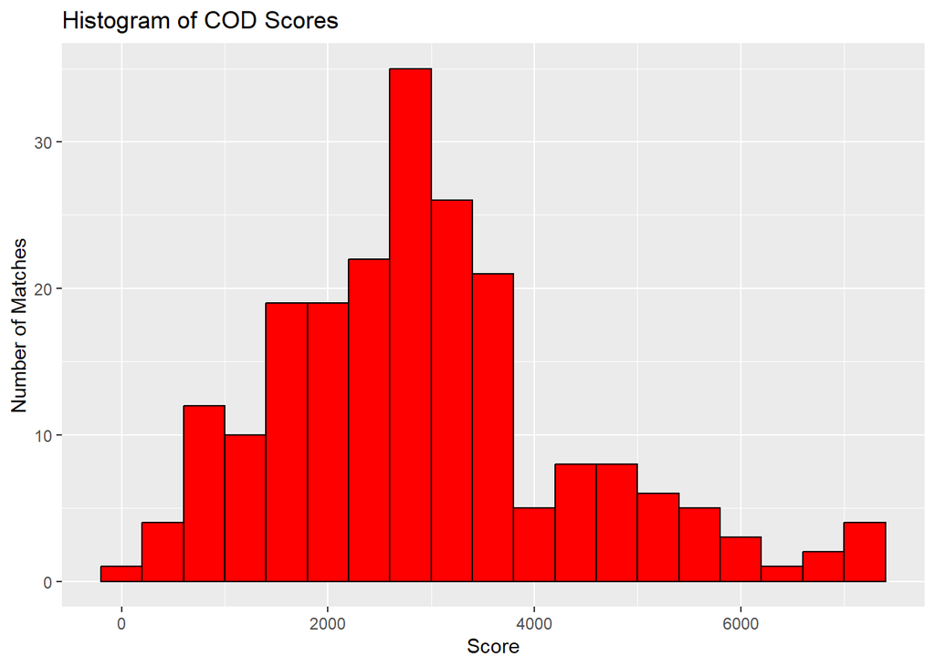

```r
# Histogram of Score variable values to show distribution
ggplot(data = COD_dataset,
  mapping = aes(x = Score)) +
  geom_histogram(binwidth = 400, fill = "red", color = "black") +
  labs(y = "Number of Matches",
  title = "Histogram of COD Scores")
```

**Analysis:**

Based on the visualization, we can see that the scores at the bottom end were 100 and at the top about 7300. The majority of scores were between 1500 and 4000. The shape of the distribution is unimodal with a right skew. The mean Score is 2,944 and the median is 2,770. On average the player had a score between 2000 and 4000, but in the right tail we see that the player occasionally managed to score above 6000.

## Variable 3 (Choice)

For the third variable, we considered the categorical variable “Choice”. The choice is between two other variables— “Map1” or “Map2”— and is determined by a third variable “MapVote”, of which a majority or equal amount of votes for Map1 meaning that it is chosen.

There is 1 `NA` value for choice.

```r
# Filter: Find the number of NA values in Choice
COD_dataset %>%
    filter(is.na(Choice)) %>%
    summarize(Number_of_NA = n())
```

```
## # A tibble: 1 × 1
##   Number_of_NA
##          <int>
## 1            1
```

Looking at the variety of map choices, there are 25 varities (not counting NA):

```r
# Table of varities of maps in Choice
COD_dataset %>%
  filter(!is.na(Choice)) %>%
  dplyr::select(Choice) %>%
  distinct()
```

```
## # A tibble: 25 × 1
##    Choice
##    <chr>
##  1 Miami Strike
##  2 Moscow
##  3 Yamantau
##  4 Drive-In
##  5 Collateral Strike
##  6 Raid
##  7 WMD
##  8 Standoff
##  9 Crossroads Strike
## 10 Deprogram
## # ℹ 15 more rows
```

**Visualization:**

```r
# Aggregate of unique map Choices and counts
COD_PW_df <- COD_dataset %>%
  select(Choice) %>%
  group_by(Choice) %>%
  summarize(N = n())

kable(COD_PW_df) # Counts of each variety
```

| Choice | N |
| --- | --- |
| Amerika | 3 |
| Apocalypse | 7 |
| Cartel | 7 |
| Checkmate | 7 |
| Collateral Strike | 12 |
| Crossroads Strike | 15 |
| Deprogram | 5 |
| Diesel | 15 |
| Drive-In | 11 |
| Echelon | 4 |
| Express | 7 |
| Garrison | 8 |
| Hijacked | 7 |
| Jungle | 4 |
| Miami Strike | 6 |
| Moscow | 5 |
| Nuketown ’84 | 9 |
| Raid | 12 |
| Rush | 15 |
| Slums | 9 |
| Standoff | 12 |
| The Pines | 5 |
| WMD | 6 |
| Yamantau | 9 |
| Zoo | 10 |
| NA | 1 |

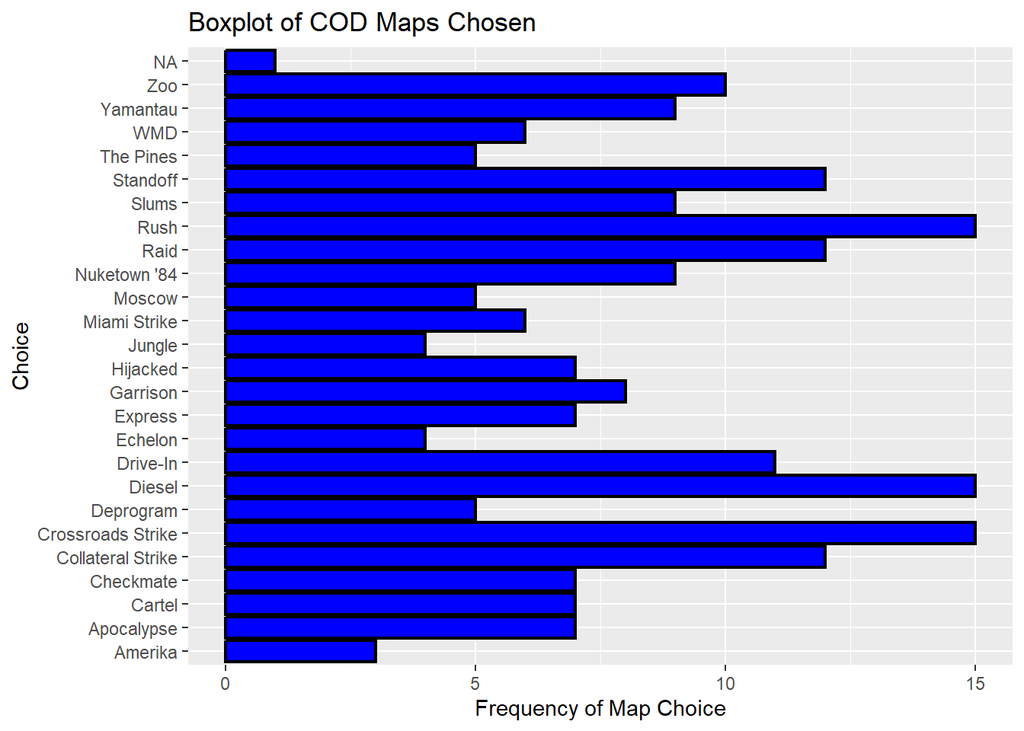

```r
# Boxplot visualization of map Choices and counts
ggplot(data = COD_PW_df,
       mapping = aes(x = N, y = Choice)) +
  geom_bar(stat = "identity", fill = "blue",
           linewidth = 0.75, colour = "black") +
  labs(x = "Frequency of Map Choice",
       title = "Boxplot of COD Maps Chosen")
```

**Analysis:**

Based on this visualization, we can observe that Maps are chosen fall within a fairly dense range: the least-chosen map, Amerika, is selected 3 times while the most-prevalent maps— Rush, Diesel, and Crossroads Strike— are selected 15 times. There appears to be a roughly random distribution of frequencies of map selection between the min and max.

## Variable 4 (Eliminations)

For the fourth variable, we examined the quantitative variable “Eliminations”. There are no `NA` values in TotalXP

```r
# Filter: Find the number of NA values in Eliminations
COD_dataset %>%
    filter(is.na(Eliminations)) %>%
    summarize(Number_of_NA = n())
```

```
## # A tibble: 1 × 1
##   Number_of_NA
##          <int>
## 1            0
```

```r
# Summary statistics for Score variable
COD_dataset %>%
  dplyr::select(Eliminations) %>%
  summarize(min = min(Eliminations),
  max = max(Eliminations),
  mean = mean(Eliminations),
  median = median(Eliminations),
  sd = sd(Eliminations))
```

```
## # A tibble: 1 × 5
##     min   max  mean median    sd
##   <dbl> <dbl> <dbl>  <dbl> <dbl>
## 1     2    39  15.1     14  6.13
```

**Visualization:**

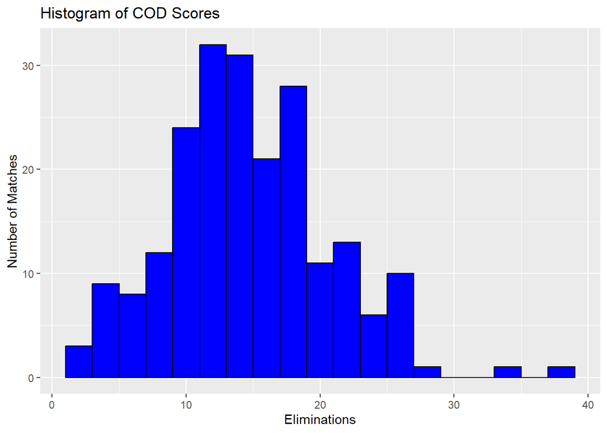

```r
# Histogram of Score variable values to show distribution
ggplot(data = COD_dataset,
  mapping = aes(x = Eliminations)) +
  geom_histogram(binwidth = 2, fill = "blue", color = "black") +
  labs(y = "Number of Matches",
  title = "Histogram of COD Scores")
```

**Analysis:**

Based on this analysis, the eliminations ranged from around 2 to around 38, with a majority of values falling between 10 and 20. The distribution of Eliminations is slightly right skewed with mean Eliminations of 15 and a median of 14. The histogram does suggest a few matches in which the player performed at a high level.

## Variable 5 (TotalXP)

For the fifth and last variable, we selected the quantitative variable TotalXP of the numeric type. There are no `NA` values in TotalXP.

```r
# Filter: Find the number of NA values in TotalXP.
COD_dataset %>%
    filter(is.na(TotalXP)) %>%
    summarize(Number_of_NA = n())
```

```
## # A tibble: 1 × 1
##   Number_of_NA
##          <int>
## 1            0
```

```r
# Summary statistics for Score variable
COD_dataset %>%
  dplyr::select(TotalXP) %>%
  summarize(min = min(TotalXP),
  max = max(TotalXP),
  mean = mean(TotalXP),
  median = median(TotalXP),
  sd = sd(TotalXP))
```

```
## # A tibble: 1 × 5
##     min   max   mean median    sd
##   <dbl> <dbl>  <dbl>  <dbl> <dbl>
## 1  1935 43816 11975.  10328 6167.
```

**Visualization:**

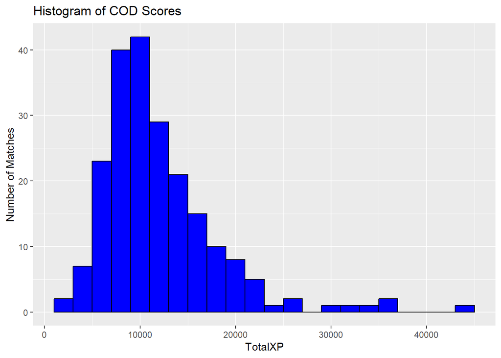

```r
# Histogram of Score variable values to show distribution
ggplot(data = COD_dataset,
  mapping = aes(x = TotalXP)) +
  geom_histogram(binwidth = 2000, fill = "blue", color = "black") +
  labs(y = "Number of Matches",
  title = "Histogram of COD Scores")
```

### 3. Begin a list of questions that you have about the dataset. Suppose you are working on a project and your manager gives you this dataset. Write 3 questions that you would ask your manager.

1. How is TotalXP calculated (what actions earn you XP)?
2. How is score calculated (what actions increase or decrease a players score)?
3. Why are there so many NA values in the last 11 columns? Why was this data not collected as frequently as the other game statistics?

### 4. Asking a question that can be answered using the dataset and data visualization.

##### **Part 1:** You will answer my question: Is the player’s performance, as quantified by the amount of experience points gained (TotalXP variable) changing over time?

1. To answer this, you should find a way to extract the month from the Date variable (we have not covered working with dates in STAT 380)
2. The lubridate package (part of tidyverse) is useful for working with dates
3. Once you have the months, create side-by-side boxplots showing the TotalXP based on the Month, where the months are named (i.e., month should be June, not the number 6).
4. The months should be in chronological order, not alphabetical order
5. Based on the plot, answer the question.
6. If you have knowledge about these types of games, you can also mention other variables that could affect TotalXP but were not included in the question.

```r
# Creating new "Month" variable
new_COD_ds <- COD_dataset %>%
  mutate(Month = month(ymd(Date), label=TRUE, abbr=FALSE))

# Table of distributions of
new_COD_ds %>%
  group_by(Month) %>%
  summarize(min = min(TotalXP),
            q1 = quantile(TotalXP, probs = 0.25),
            median = median(TotalXP),
            q3 = quantile(TotalXP, probs = 0.75),
            max = max(TotalXP))
```

```
## # A tibble: 3 × 6
##   Month    min    q1 median     q3   max
##   <ord>  <dbl> <dbl>  <dbl>  <dbl> <dbl>
## 1 June    3795 8525. 11078. 14033. 33645
## 2 July    1935 7434   9872  14060  43816
## 3 August  5949 8556. 10142. 14215. 30977
```

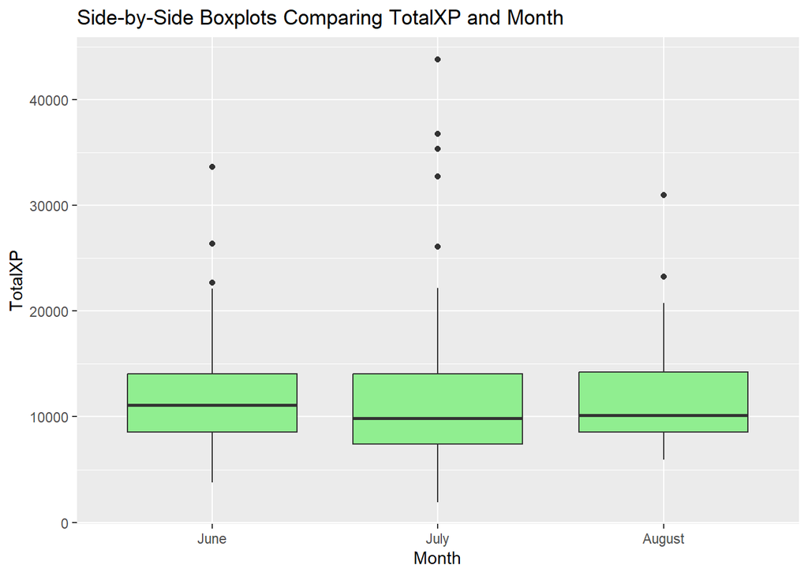

```r
# Side-by-side boxplots of TotalXP, divided by Month
ggplot(data = new_COD_ds, mapping = aes(x = Month, y = TotalXP)) +
  geom_boxplot(fill = "lightgreen") +
  labs(title = "Side-by-Side Boxplots Comparing TotalXP and Month")
```

1. June’s median TotalXP outstrips either of the other months, being 1,206XP and 936XP greater than July and August’s median TotalXP respectively.
2. July’s interquartile range (IQR) is slightly wider: specifically, its first quartile is roughly 1,000XP lower than June and August’s.

These differences suggest that, while not strong, TotalXP *does* vary between months of the year, which might affect, and therefore be worth considering, for those COD players who play at the highest level of the game.

##### **Part 2:** You will write your own question, create a data visualization that can help answer your question, and write an answer to your question.

1. The question/visualization should explore the relationship between at least 2 of the variables in the dataset.
2. Be sure you include both the question and the answer to your question based on the visualization you have created.

**New Question:** Is the primary weapon selected related to the number of eliminations?

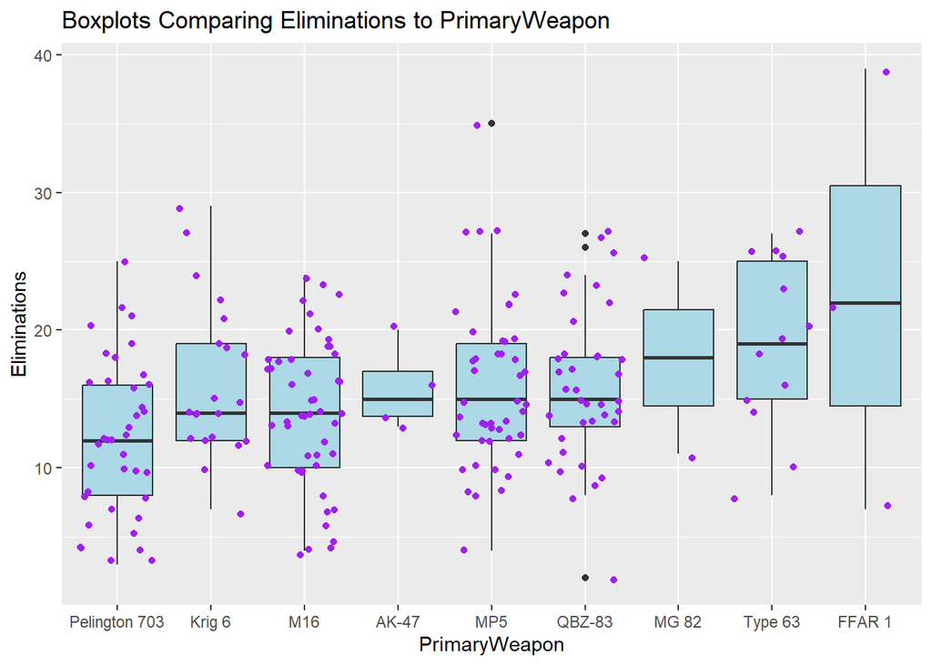

```r
# Visualization of PrimaryWeapons and Elimination count
ggplot(data = COD_dataset,
       mapping = aes(x = reorder(PrimaryWeapon, Eliminations, median),
                     y = Eliminations),
                     group = PrimaryWeapon) +
  geom_boxplot(fill = "lightblue") +
  geom_point(position = "jitter", color = "purple") +
  labs(x = "PrimaryWeapon",
       title = "Boxplots Comparing Eliminations to PrimaryWeapon")
```

Notably, this first visualization contains three weapons which were selected less than 5 times— the FFAR 1, the MG 82, and AK-47— which make them outliers which might skew the conclusion regarding average Eliminations based on their medians having the same weight as weapons with a lot of data supporting the median (e.g., the Pelington 703). Therefore, let’s create a second visualization discounting those.

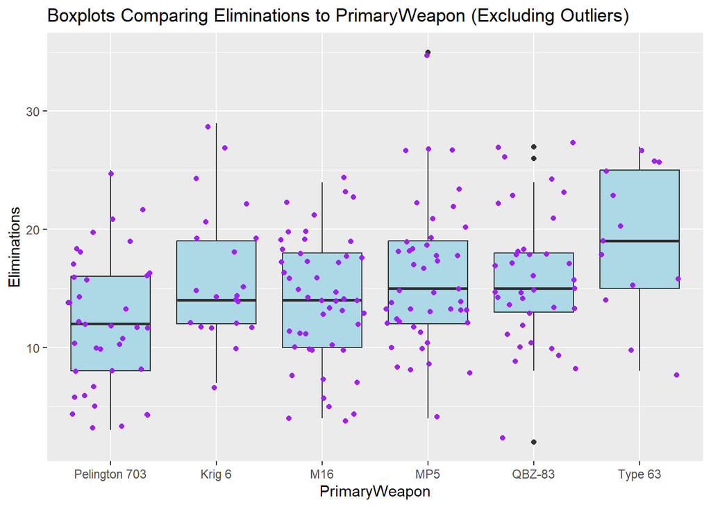

```r
# Visualization w/o outlier weapons
filtered_COD_ds <- COD_dataset %>%
  filter(!(PrimaryWeapon %in% c("FFAR 1", "MG 82", "AK-47")))

ggplot(data = filtered_COD_ds,
       mapping = aes(x = reorder(PrimaryWeapon, Eliminations, median),
                     y = Eliminations),
                     group = PrimaryWeapon) +
  geom_boxplot(fill = "lightblue") +
  geom_point(position = "jitter", color = "purple") +
  labs(x = "PrimaryWeapon",
       title = "Boxplots Comparing Eliminations to PrimaryWeapon (Excluding Outliers)")
```

1. Between the PrimaryWeapon with the most eliminations behind it, the Type 63 with 19 eliminations, and the one with the least, the Pelington 703 with 12 eliminations, there is a 7-elimination gap.
2. Comparing the Pelington 703 and the second-most elimination Primary Weapon, the QBZ-83 with 15 eliminations, there is a substantial 3-elimination gap (a 25% increase from the Pelington).
3. Comparing the second-least Eliminations and second-most Eliminations weapons— the Krig 6 and the QBZ-83— is finally where there is only a 7% difference from 14 to 15 eliminations.